# GRUPAL SUICIDIOS

Jorge Sillero

2024-02-24

# ¿Cómo ha evolucionado la tasa de suicidios de todos los paises a lo largo de los últimos años?

Librerías

```r
library(shiny)
library(plotly)
library(dplyr)
library(countrycode)
```

## Lectura del Dataset

```r
suicide_data <- read.csv("data/1.OMSTasaMortalidadSuicidio/tasa_suicidio_por_pais.csv")

head(suicide_data)
```

```
##         GEO_NAME_SHORT DIM_TIME DIM_SEX VALUE_NUMERIC
## 1          Afghanistan     2000   Total        4.9100
## 2          Afghanistan     2000  Female        4.7900
## 3          Afghanistan     2000    Male        5.0300
## 4               Africa     2000    Male       13.5030
## 5               Angola     2000    Male       14.2193
## 6 United Arab Emirates     2000    Male       10.8366
```

```r
summary(suicide_data)
```

```
##  GEO_NAME_SHORT        DIM_TIME      DIM_SEX          VALUE_NUMERIC
##  Length:17679       Min.   :2000   Length:17679       Min.   :  0.00
##  Class :character   1st Qu.:2007   Class :character   1st Qu.:  4.08
##  Mode  :character   Median :2015   Mode  :character   Median :  7.90
##                     Mean   :2013                      Mean   : 13.65
##                     3rd Qu.:2019                      3rd Qu.: 14.47
##                     Max.   :2019                      Max.   :646.03
```

Este archivo CSV contiene los datos de las tasa de suicidio de cada país desde el 2000 hasta el 2019. Previo a esta lectura, ya que es un dataset que se ha usado para las preguntas grupales, se ha realizado un preprocesado (Documento PreprocesadoDatasetSuicidios), que básicamente consistía en eliminar diferentes columnas que no nos aportaban valor para nuestros experimentos.

Los atributos que contiene este dataset son:

- GEO_NAME_SHORT: nombre de cada país.
- DIM_TIME: año.
- DIM_SEX: subgrupo del país según el sexo. (Total, Male, Female)
- VALUE_NUMERIC: tasa de suicidio por cada 100.000 habitantes.

Para nuestro experimento, únicamente necesitamos la tasa de suicidios total del país, no por los diferentes sexos. También eliminamos el año 2019 porque presenta unos datos que no son realistas comprobando con otras fuentes que representan datos similares.

```r
suicide_data_total <- suicide_data %>% filter(DIM_SEX == "Total"& DIM_TIME != 2019)
```

## Visualizaciones

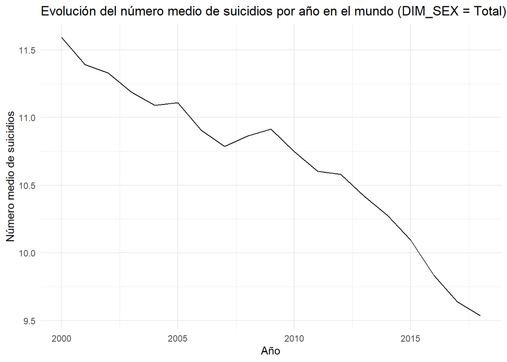

```r
# Calcular la media de los valores de suicidios para cada año
datos_globales <- aggregate(VALUE_NUMERIC ~ DIM_TIME, data = suicide_data_total, mean)

# Crear un gráfico de líneas utilizando ggplot
ggplot(datos_globales, aes(x = DIM_TIME, y = VALUE_NUMERIC)) +
  geom_line() +
  labs(title = "Evolución del número medio de suicidios por año en el mundo (DIM_SEX = Total)",
       x = "Año",
       y = "Número medio de suicidios") +
  theme_minimal()
```

Como se puede observar, y para nuestra sorpresa y agrado, la tasa de suicidios ha ido decrementado en los últimos años significativamente, teniendo algunos picos, pero manteniendo una bajada constante.

Una vez hemos visto esta gráfica, vamos a mostrar la evolución por cada país gracias a una visualización iteractiva.

Para ello, es necesario en primer lugar añadir una columna que contenga el código de cada país segun el ISO3

```r
suicide_data_total$iso3 <- countrycode(suicide_data_total$GEO_NAME_SHORT, "country.name", "iso3c")
head(suicide_data_total)
```

```
##         GEO_NAME_SHORT DIM_TIME DIM_SEX VALUE_NUMERIC iso3
## 1          Afghanistan     2000   Total        4.9100  AFG
## 2               Africa     2000   Total        9.2100 <NA>
## 3 United Arab Emirates     2000   Total        8.6000  ARE
## 4  Antigua and Barbuda     2000   Total        1.9400  ATG
## 5               Angola     2000   Total        8.7100  AGO
## 6              Burundi     2000   Total       11.6728  BDI
```

Y, por último, realizamos la visualización interactiva.

```r
suicide_data_total$DIM_TIME <- as.character(suicide_data_total$DIM_TIME)

# UI
ui <- fluidPage(
  titlePanel("Mapa Interactivo de Tasa de Suicidios por País"),
  sidebarLayout(
    sidebarPanel(
      sliderInput("yearSlider",
                  "Año:",
                  min = min(as.numeric(suicide_data_total$DIM_TIME)),
                  max = max(as.numeric(suicide_data_total$DIM_TIME)),
                  value = min(as.numeric(suicide_data_total$DIM_TIME)),
                  step = 1,
                  animate = TRUE)
    ),
    mainPanel(
      plotlyOutput("suicideMap")
    )
  )
)

# Server
server <- function(input, output) {
  output$suicideMap <- renderPlotly({
    # Filtrar datos basados en el año seleccionado
    filtered_data <- suicide_data_total %>%
      filter(DIM_TIME == input$yearSlider)

    # Crear el mapa plotly con datos filtrados
    fig <- plot_geo(filtered_data, locations = ~iso3, color = ~VALUE_NUMERIC,
                    text = ~paste(GEO_NAME_SHORT, ": ", VALUE_NUMERIC),
                    colors = "Blues") %>%
      colorbar(title = "Tasa de Suicidio", limits = c(0, 50)) %>%
      layout(title = paste('Tasa de Suicidio por País en el Año', input$yearSlider),
             geo = list(showframe = FALSE, showcoastlines = TRUE, projection = list(type = 'natural earth')))

    fig
  })
}

# Ejecuta la aplicación
shinyApp(ui = ui, server = server)
```

Shiny applications not supported in static R Markdown documents